# Text Analysis at IQMR 2

- Show All Code
- Hide All Code
- View Source

Author

Michelle Bueno Vásquez

Published

June 21, 2024

**Note**

All credit for these materials go to Professor Ben Noble, I just compiled it into a nice html format

# Lab 4: Predicting Nostalgia

You will need to install the `dataverse` package (and the other packages mentioned):

```r
library(glmnet)
library(tidyverse)
library(dataverse)
library(quanteda)
```

[Data comes from Muller and Proksch (2023)](https://www.cambridge.org/core/journals/british-journal-of-political-science/article/nostalgia-in-european-party-politics-a-textbased-measurement-approach/41C48D60B039F3081EB522FB76646E96#article)

```r
nostalgia <- get_dataframe_by_name(
  filename = "data_coded_all.tab",
  dataset = "https://doi.org/10.7910/DVN/W8VGJF",
  server = "dataverse.harvard.edu")
```

### Here, we will create three different sets, our training, test, and validation

```r
# sets
set.seed(20240612)
# randomly sample 30% of the data for testing and validating
test_ids <- sample(nostalgia$doc_id, nrow(nostalgia) * 0.3)
# hold out 10% of the total df for our final validation
held_out_ids <- sample(test_ids, length(test_ids) * (1/3))
# get the other 20% as test data
test_set <- nostalgia %>% filter(doc_id %in% test_ids & !doc_id %in% held_out_ids)
# finally, get our training data
train_set <- nostalgia %>% filter(!doc_id %in% test_ids)
```

Then we use some standard pre-processing to construct our dfm

```r
nostalgia_train_dfm <- corpus(train_set) %>%
    tokens(remove_numbers = TRUE,
        remove_punct = TRUE,
        remove_symbols = TRUE,
        remove_separators = TRUE) %>%
    tokens_tolower() %>%
    tokens_remove(c(stopwords("english"))) %>%
    tokens_select(min_nchar = 3) %>%
    dfm() %>%
    dfm_wordstem() %>%
    dfm_trim(min_termfreq = 10, termfreq_type = 'count',
        min_docfreq = 10, docfreq_type = 'count')
```

Now, we train our lasso model:

We will also use a logit model here to predict a binary class

**Note**

alpha = 1 is for lasso.

this will do cross validation to select the best $\lambda$

```r
cv_model <- cv.glmnet(nostalgia_train_dfm, train_set$nostalgic, alpha = 1, family = "binomial")
```

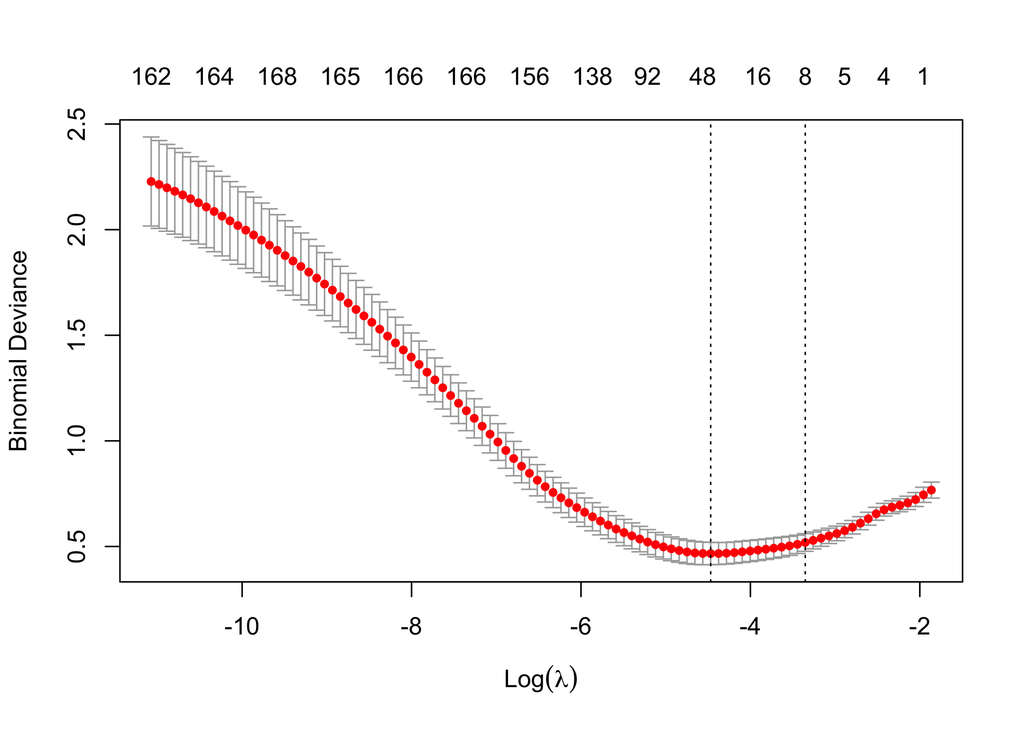

```r
plot(cv_model)
```

We can view inside the model object here

```r
log(cv_model$lambda.min)
```

```
[1] -4.468698
```

We can also visualize the shrinkage process

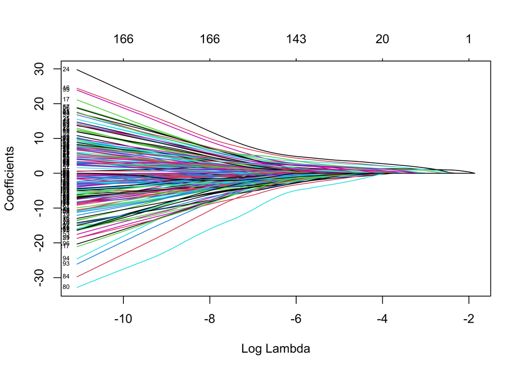

```r
plot(cv_model$glmnet.fit,
     xvar = "lambda",
     label = TRUE)
```

Let’s look at the most important coefficients as identified by the model

```r
best_coefs <- coef(cv_model,
                   s = "lambda.min")
```

```r
head(sort(best_coefs[,1]))
```

```
(Intercept)       rural         new       first        fund     protect
 -3.3559306  -1.5207569  -0.8580014  -0.7058376  -0.4666257  -0.3511841
```

### Testing model on test data

Let’s turn to testing how well our model performs on our test data

To do so, we need to create a dfm that only includes words used to train the model (our model wouldn’t know what to do with a word outside of its vocab)

We will pre-process test data using the same pre-processing steps

```r
test_dfm <- corpus(test_set)  %>%
    tokens(remove_numbers = TRUE,
        remove_punct = TRUE,
        remove_symbols = TRUE,
        remove_separators = TRUE) %>%
    tokens_tolower() %>%
    tokens_remove(c(stopwords("english"))) %>%
    tokens_select(min_nchar = 3) %>%
    dfm() %>%
    dfm_wordstem() %>%
    dfm_trim(min_termfreq = 10, termfreq_type = 'count',
        min_docfreq = 10, docfreq_type = 'count')
```

Match terms between training and test

```r
matched_test_terms <- dfm_match(test_dfm,
                                features = featnames(nostalgia_train_dfm))
```

### Predict a probability

We can now predict the probability any given document in our test set is nostalgic, the output is a probability

```r
predictions <- predict(cv_model,
                       newx = matched_test_terms,
                       s = "lambda.min",
                       type = "response")
```

### Let’s look to see some representative texts

This is the text that is predicted to be most nostalgic:

```r
nostalgia %>% filter(doc_id ==
                       rownames(predictions)[
                         which.max(predictions)
                         ]) %>%
  pull(text)
```

```
[1] "Left also wants the return of Norwegian Cultural Heritage Fund used as grants / loans to cultural heritage projects."
```

and here is the least nostalgic:

```r
nostalgia %>% filter(doc_id ==
                       rownames(predictions)[
                         which.min(predictions)
                         ]) %>% pull(text)
```

```
[1] "In the face of this grave employment situation, and that of young people in particular, it is necessary, to prevent that this becomes an excuse for new environmental havoc instead necessary that environmental policies are the occasion of new jobs and no longer a constraint."
```

Seems pretty good!

### “Round” off the probabilities

We can also use predict to “round” off the probabilities and give us a 0/1

```r
predictions_class <- predict(cv_model,
                             newx = matched_test_terms,
                             s = "lambda.min",
                             type = "class")
```

### Confusion Matrix

We can create a confusion matrix to see how we did

```r
conf_mat <- table(true = test_set$nostalgic,
                  pred = as.numeric(predictions_class))
```

#### Measuring accuracy:

```r
(conf_mat[1,1] + conf_mat[2,2])/sum(conf_mat)
```

```
[1] 0.9291667
```

Accuracy is 92%, which is quite good

#### Proportion of 1s that were actually correct:

```r
conf_mat[2,2]/sum(conf_mat[,2])
```

```
[1] 0.8666667
```

**Tip**

But note that nostalgia is rare, so we can get good accuracy just by defaulting to 0 precision tells us proportion of 1s that were actually correct 87% because it very rarely said 1 when it was 0

##### Propotion of actual positives:

```r
conf_mat[2,2]/sum(conf_mat[2,])
```

```
[1] 0.4642857
```

**Tip**

This tell us proportion of actual positives that were identified correctly … only 46%, very bad!

#### So the model under-predicts nostalgia, what should we do?

We could try different pre-processing, use different model(s), code more docs

(Time permitting) Try to replicate the training process on the training and test data and predict on the test data here are the datasets you’ll need to get your started

```r
held_out <- nostalgia %>% filter(doc_id %in% held_out_ids)
train_and_test <- nostalgia %>% filter(!doc_id %in% held_out_ids)
```

# Lab 5

## Part I: GloVe “by hand”

Let’s get a better understanding of how the GloVe algorithm (and word embeddings generally) work by walking through the GloVe algorithm. To begin our discussion, let’s try to fit a GloVe embedding model on the full text of Dr. Seuss’s Green Eggs and Ham. Famously, Dr. Suess’s editor bet him that he could not write a book using just 50 words, and Green Eggs and Ham was the result.

We can read in the text of green eggs and ham:

```r
corpus <- readLines('https://www.site.uottawa.ca/~lucia/courses/2131-02/A2/trythemsource.txt')[-c(1,117)]

# Lower case and create individual tokens
tokens <- unlist(strsplit(tolower(corpus), "\\W+"))

# Remove empty space
tokens <- tokens[tokens != '']

# unique vocabulary
vocab <- unique(tokens)

# number of unique terms
vocab_size <- length(vocab)

# Assign each word a unique id number
vocab_index <- setNames(seq_along(vocab), vocab)
```

### Function to create a co-occurrence matrix

**Note**

Note, we set the context window size to three words on either side (aka, 6)

Steps the code below will take: - Initialize an empty co-occurrence matrix with dimensions equal to the vocabulary size - Loop over each token in the tokenized text - Print the current index to track progress - Get the current token and its index in the vocabulary - Define the window range around the current token - Loop over the context window - Skip the current token itself - Get the context token and its index in the vocabulary - Increment the co-occurrence count for the token-context pair - Return the filled co-occurrence matrix

```r
create_cooccurrence_matrix <- function(tokens,
                                       vocab_index,
                                       window_size = 3) {
  cooccurrence_matrix <- matrix(0,
                                nrow = length(vocab_index),
                                ncol = length(vocab_index))
  for (i in seq_along(tokens)) {
    print(i)
    token <- tokens[i]
    token_index <- vocab_index[[token]]
    window_start <- max(1, i - window_size)
    window_end <- min(length(tokens), i + window_size)
    for (j in window_start:window_end) {
      if (i != j) {
        context_token <- tokens[j]
        context_index <- vocab_index[[context_token]]
        cooccurrence_matrix[token_index, context_index] <-
          cooccurrence_matrix[token_index, context_index] + 1
      }
    }
  }
  return(cooccurrence_matrix)
}
```

### Create co-occurrence matrix

```r
cooccurrence_matrix <- create_cooccurrence_matrix(tokens, vocab_index)
# assign text names
rownames(cooccurrence_matrix) <- vocab
colnames(cooccurrence_matrix) <- vocab
# print first few rows
head(cooccurrence_matrix)

set.seed(20240616)
```

### Initialize word vectors and biases

```r
# Set our embedding dimensions to 50
embedding_dim <- 50

# We initialize word and context vectors with random values
word_vectors <- matrix(runif(vocab_size * embedding_dim,
                             -0.5, 0.5),
                       nrow = vocab_size)

context_vectors <- matrix(runif(vocab_size * embedding_dim,
                                -0.5, 0.5),
                          nrow = vocab_size)

# Same for the bias terms
word_bias <- runif(vocab_size, -0.5, 0.5)
context_bias <- runif(vocab_size, -0.5, 0.5)
```

```r
# Cosine similarity function
cos_sim <- function(vector1, vector2){
  numerator <- sum(vector1 * vector2)
  denominator <- sqrt(sum(vector1^2)) * sqrt(sum(vector2^2))
  cs <- numerator/denominator
  return(cs)
}
```

Note: we combine word and context vectors to capture word similarities when $word_i$ is the target and when it is in the context of other words

```r
first_embeddings <- word_vectors + context_vectors
ham_emb <- first_embeddings[vocab_index['ham'],]
egg_emb <- first_embeddings[vocab_index['eggs'],]
fox_emb <- first_embeddings[vocab_index['fox'],]
```

### Cosine similarity of ham and eggs, of ham and fox

Note that ham and eggs are less similar than ham and fox to start due to randomization

```r
cos_sim(ham_emb, egg_emb)
```

```
[1] -0.3303826
```

```r
cos_sim(ham_emb, fox_emb)
```

```
[1] -0.1402492
```

### Training parameters

How quickly the model updates

```r
learning_rate <- 0.05
```

These two parameters control the weights applied which helps account for words that co-occur frequently (e.g., “the”)

```r
x_max <- 50
alpha <- 0.75
```

How many model iterations we’ll run

```r
iterations <- 100
```

Create some empty vectors to store the running cosine similarity of vectors of interest for demo purposes

```r
cs_hamegg <- cs_hamfox <- c()
```

Number of iterations for training

```r
for (iter in 1:iterations) {
  print(iter)
  for (i in 1:vocab_size) {
    for (j in 1:vocab_size) {
      if (cooccurrence_matrix[i, j] > 0) {
        weight <- (cooccurrence_matrix[i, j] / x_max)^alpha
        weight <- ifelse(weight > 1, 1, weight)
        dot_product <- sum(word_vectors[i, ] * context_vectors[j, ])
         cost <- dot_product + word_bias[i] + context_bias[j] - log(cooccurrence_matrix[i, j])
         word_grad <- weight * cost * context_vectors[j, ]
         context_grad <- weight * cost * word_vectors[i, ]
         word_bias_grad <- weight * cost
         context_bias_grad <- weight * cost
         word_vectors[i, ] <- word_vectors[i, ] - learning_rate * word_grad
         context_vectors[j, ] <- context_vectors[j, ] - learning_rate * context_grad
         word_bias[i] <- word_bias[i] - learning_rate * word_bias_grad
          context_bias[j] <- context_bias[j] - learning_rate * context_bias_grad

      }
    }
  }
  # Print a message indicating the completion of the current iteration
  cs_hamegg <- c(cs_hamegg, cos_sim(word_vectors[vocab_index['ham'],] + context_vectors[vocab_index['ham'],], word_vectors[vocab_index['eggs'],] + context_vectors[vocab_index['eggs'],]))
  cs_hamfox <- c(cs_hamfox, cos_sim(word_vectors[vocab_index['ham'],] + context_vectors[vocab_index['ham'],], word_vectors[vocab_index['fox'],] + context_vectors[vocab_index['fox'],]))
  cat("Iteration:", iter, "completed\n")
}
```

- Print the current iteration to track progress
- Loop over each word in the vocabulary
- Loop over each context word in the vocabulary
- Only update if the co-occurrence count is greater than zero
- Calculate the weighting function f(X_ij)
- Cap the weight at 1
- Compute the dot product of the word and context vectors
- Calculate the cost function J for the given word-context pair
- Compute the gradient for the word vector
- Compute the gradient for the context vector
- Compute the gradient for the word bias
- Compute the gradient for the context bias
- Update the word vector using the gradient
- Update the context vector using the gradient
- Update the word bias using the gradient
- Update the context bias using the gradient